# EDA Code Notebook

Group 5

2024-10-03

# Introduction

As college students studying social sciences, we are acutely aware of the multifaceted challenges within the educational system, such as disparities in access to quality education and the persistent achievement gaps across demographic groups. Our analysis leverages the Common Core of Data (CCD), maintained by the U.S. Department of Education, which catalogs comprehensive information on public elementary and secondary schools and districts across the United States from 2005 to 2015. This dataset not only aligns with our academic interests but also serves as a practical application of our data analysis skills to a field we are passionate about—education.

The CCD includes a broad array of variables, totally 99, ranging from graduation rates and standardized test scores to teacher qualifications and student-teacher ratios. While this wealth of data offers a broad lens to view the educational landscape, for our specific inquiry into educational inequalities, many of these variables are peripheral. Therefore, to deepen our analysis and maintain clarity in our investigation, we have chosen to focus on a subset of variables that directly relate to academic outcomes and socio-economic factors, such as demographics, test scores, academic achievements, and family income.

This targeted approach is not merely a methodological choice but a strategic one influenced by our position as students; it allows us to more effectively explore and interpret the complex relationships that drive educational outcomes. By narrowing our focus, we aim to provide a clearer, more detailed examination of how various factors impact student performance across different regions and demographic groups. This streamlined analysis is intended to identify leverage points for policy intervention and to generate insights that are both academically rigorous and socially relevant.

Moreover, given that the data spans up to nearly a decade ago, we acknowledge the potential limitations in reflecting the current educational climate. However, our focus on historical data provides a foundational understanding of trends and issues that remain relevant in today’s discourse on educational equity.

```r
#Load the dataset
score<-read.csv("data/school_scores.csv")
```

```r
#Inspect the dataset
# head(score)
```

# Data Cleaning/Simplifying

It is shown that there are 99 variables total in this dataset, which is too many for our analysis. Since our purpose of analysis is to investigate disparities and inequalities in educational outcomes across different regions and demographic groups, we decided to subset the dataset with the variables we think that are useful for our analysis.

```r
# Subset the dataset with relevant variables
demographic_vars <- c("Year", "State.Code", "State.Name")
test_score_vars <- c("Total.Math", "Total.Test.takers", "Total.Verbal",
                     "Gender.Female.Math", "Gender.Female.Test.takers" , "Gender.Female.Verbal",
                     "Gender.Male.Math", "Gender.Male.Test.takers","Gender.Male.Verbal")
academic_vars <- c("Academic.Subjects.English.Average.GPA", "Academic.Subjects.Mathematics.Average.GPA")
income_vars <- grep("Family.Income", colnames(score), value = TRUE)
gpa_vars <- grep("^GPA", colnames(score), value = TRUE)
```

```r
# Combine all selected variables into one vector
selected_vars <- c(demographic_vars, test_score_vars, academic_vars, income_vars, gpa_vars)
```

```r
# Subset the dataset
score_subset <- score %>%
  select(all_of(selected_vars))
```

```r
# Check the structure of the new subset
#str(score_subset)
# head(score_subset)
```

Explanation of not including the result of str() and head():

In this analysis, while the str() and head() functions are implemented to ensure comprehensive data understanding and quality assurance, their outputs are not included directly in the initial sections of this document. This decision is made to prevent an overwhelming volume of preliminary data from cluttering the documentation, considering the dataset contains 53 variables. Including such detailed outputs from the outset could potentially expand the final report to an impractical length, estimated to exceed 300 pages.

Overview of dataset:

The summary function provides basic information for each variable. However, since the dataset contains many variables, including the full summary in the final notebook would make it difficult to navigate as mentioned above. Therefore, we’ve commented out the summary to keep the notebook more readable. In our subsequent EDA, we provide a more detailed analysis of the variable distributions, ensuring that both machine and human audiences will still have a clear understanding of the data. This approach strikes a balance between readability and providing essential insights.

```r
#save the new subset to a file
write_csv(score_subset, "data/school_scores_subset.csv")
```

By the code above, we reduced the variables from 99 to 53, leaving the ones we think are potentially insightful only.

# Breakdown & Analysis

## Theme 1: Demographic information

The dataset contains basic demographic information that helps identify the year and the state in which the data was collected. These variables include:

- Year: The year the data was recorded.
- State.Code: The two-letter abbreviation of the state.
- State.Name: The full names of the states.

```r
demographic_data <- score_subset[, demographic_vars]
head(demographic_data)
```

```
##   Year State.Code State.Name
## 1 2005         AL    Alabama
## 2 2005         AK     Alaska
## 3 2005         AZ    Arizona
## 4 2005         AR   Arkansas
## 5 2005         CA California
## 6 2005         CO   Colorado
```

### Map

First of all, we want to use a map to visualize the total number of test takers by state because it highlights regional disparities in test participation, helping to identify areas with low engagement with education. This visualization shows unequal resource allocation and informing policies that can improve access to testing. By visualizing this data, we can better understand where educational interventions are most needed to promote equity across states.

Firstly, we would load the dataset,ensure the summarized data is correct before proceeding with map-related steps.

```r
# Summarize the total test takers by state
state_test_takers <- score_subset %>%
  group_by(State.Code) %>%
  summarise(total_takers = sum(Total.Test.takers, na.rm = TRUE))
```

Next, we would prepare the data ready to be put on a map by cleaning the dataset and merge by state names.

```r
# Get U.S. states map data
states_map <- map_data("state")

# Convert state codes to lowercase for matching
state_test_takers$region <- tolower(state.name[match(state_test_takers$State.Code, state.abb)])

# Merge test takers data with the map data, making sure to keep 'group' column from states_map
map_data_merged <- left_join(states_map, state_test_takers, by = "region")

# Fill missing total_takers with 0 (or another value)
map_data_merged$total_takers[is.na(map_data_merged$total_takers)] <- 0

# Calculate centroids (average latitude and longitude) for each state
state_centroids <- map_data_merged %>%
  group_by(region) %>%
  summarise(long = mean(long), lat = mean(lat))

# Add the state abbreviations (State.Code) to the centroids data
state_centroids$State.Code <- state_test_takers$State.Code[match(state_centroids$region, state_test_takers$region)]
```

Finally, we put the data on map.

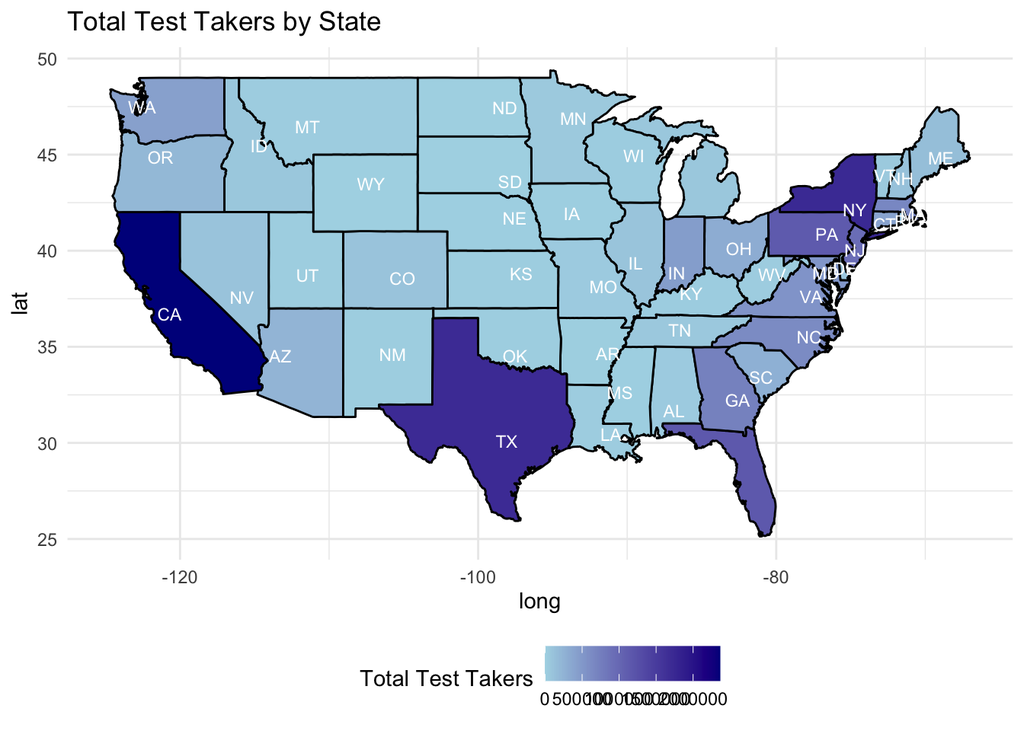

```r
# Plot the map with state abbreviations
ggplot() +
  geom_polygon(data = map_data_merged, aes(x = long, y = lat, group = group, fill = total_takers), color = "black") +
  geom_text(data = state_centroids, aes(x = long, y = lat, label = State.Code), size = 3, color = "white") +
  scale_fill_continuous(name = "Total Test Takers", low = "lightblue", high = "darkblue", na.value = "grey50") +
  theme_minimal() +
  labs(title = "Total Test Takers by State") +
  theme(legend.position = "bottom")
```

## Theme 2: Test Scores

Test scores represent one of the core components of our dataset. These variables include overall test scores, family income group test scores, and test scores based on GPA. Here are the variables:

- Total.Test.takers: The number of test-takers in this state during this year
- Gender.Female.Test,takers: The number of test-takers in this state during this year who identified as female
- Gender.Male.Test,takers: The number of test-takers in this state during this year who identified as male
- Total.Math: The average Math score of students in this state during this year
- Total.Verbal: The average Verbal score of students in this state during this year
- Gender.Female(Male).Math: The average Math score of students in this state during this year who identified as female(male)
- Gender.Female(Male).Verbal: The average Verbal score of students in this state during this year who identified as female(male)

```r
test_score_data <- score_subset[, test_score_vars]
head(test_score_data)
```

```
##   Total.Math Total.Test.takers Total.Verbal Gender.Female.Math
## 1        559              3985          567                538
## 2        519              3996          523                505
## 3        530             18184          526                513
## 4        552              1600          563                536
## 5        522            186552          504                504
## 6        560             11990          560                546
##   Gender.Female.Test.takers Gender.Female.Verbal Gender.Male.Math
## 1                      2072                  561              582
## 2                      2161                  521              535
## 3                      9806                  522              549
## 4                       859                  558              570
## 5                    102944                  499              543
## 6                      6407                  558              577
##   Gender.Male.Test.takers Gender.Male.Verbal
## 1                    1913                574
## 2                    1835                526
## 3                    8378                531
## 4                     741                570
## 5                   83608                510
## 6                    5583                561
```

### Total Scores Analysis

We plotted a histogram of total math and verbal scores to understand the distribution of scores across the sample. The histogram shows how frequently different score ranges occur.

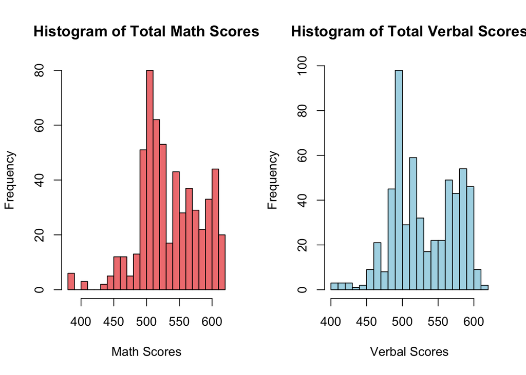

```r
par(mfrow = c(1, 2))

# Plot histogram for Total Math Scores
hist(test_score_data$Total.Math,
     breaks = 20,
     main = "Histogram of Total Math Scores",
     xlab = "Math Scores",
     col = "lightcoral",
     border = "black")

# Plot histogram for Total Verbal Scores
hist(test_score_data$Total.Verbal,
     breaks = 20,
     main = "Histogram of Total Verbal Scores",
     xlab = "Verbal Scores",
     col = "lightblue",
     border = "black")
```

```r
par(mfrow = c(1, 1))
```

To better assess whether these distributions follow a normal distribution, we will next perform a QQ plot (quantile-quantile plot) to visually check for normality. The QQ plot will allow us to see if the observed scores deviate significantly from a theoretical normal distribution.

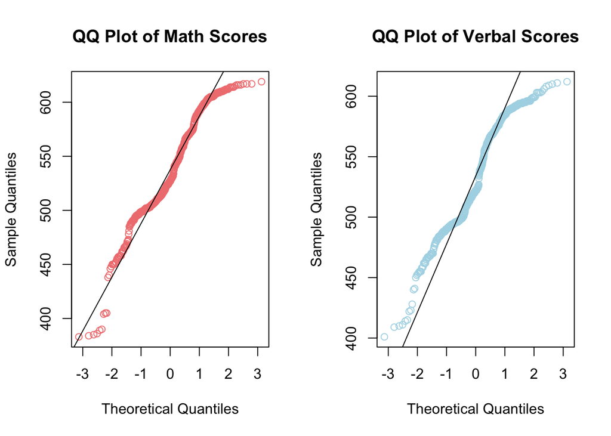

```r
par(mfrow = c(1, 2))

# QQ plot for Total Math Scores
qqnorm(test_score_data$Total.Math, main = "QQ Plot of Math Scores", col = "lightcoral")
qqline(test_score_data$Total.Math, col = "black")

# QQ plot for Total Verbal Scores
qqnorm(test_score_data$Total.Verbal, main = "QQ Plot of Verbal Scores", col = "lightblue")
qqline(test_score_data$Total.Verbal, col = "black")
```

```r
par(mfrow = c(1, 1))
```

We observe that both math and verbal scores show some degree of deviation from a normal distribution, especially at the extremes. However, the data mostly follows a normal pattern, with only slight non-normality, especially at the higher ends.

To further explore this relationship, we generated a scatter plot to visualize the correlation between math and verbal scores. Each point on the graph represents an individual student’s performance in both areas, offering a clearer view of how these two variables may interact. This visual representation helps highlight any patterns or outliers, allowing us to assess whether the non-normality at the extremes is reflected in the correlation between the two variables.

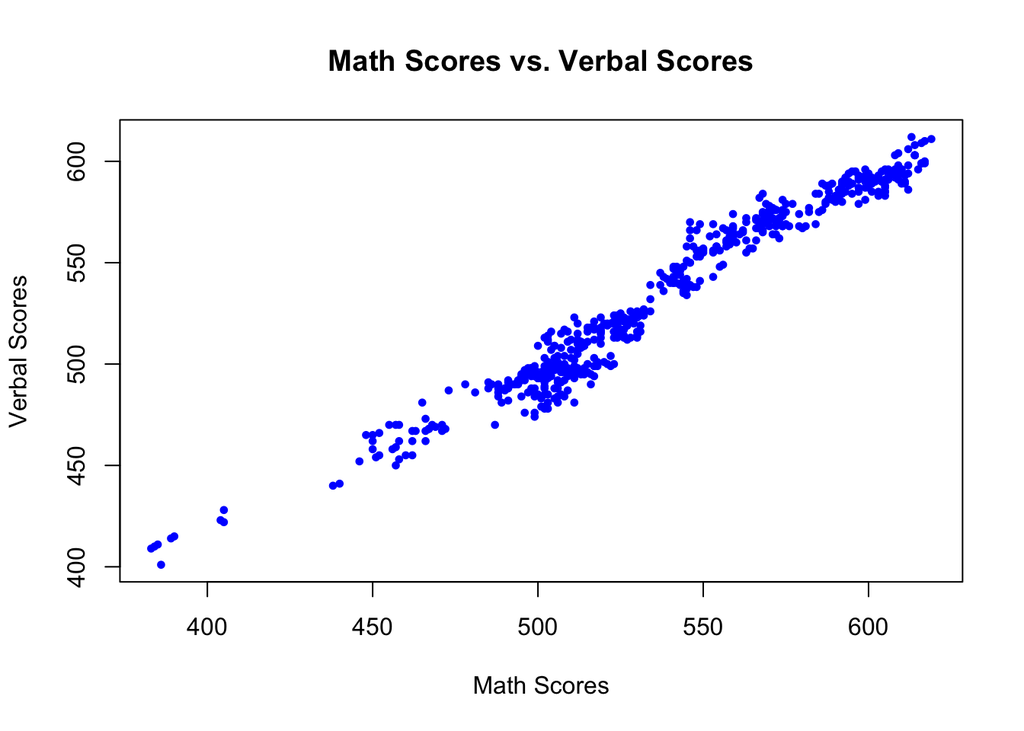

```r
plot(test_score_data$Total.Math, test_score_data$Total.Verbal,
     main = "Math Scores vs. Verbal Scores",
     xlab = "Math Scores",
     ylab = "Verbal Scores",
     pch = 19,
     col = "blue",
     cex = 0.6)
```

The scatter plot shows a strong positive relationship between math and verbal scores. As math scores increase, verbal scores tend to increase as well, indicating that students who perform well in math also tend to score higher in verbal sections.

To better analyze, We plotted a line graph to find the trend of average math and verbal scores over the years. The graph shows the changes in average scores for each test type from 2005 to 2015, with a blue line representing math scores and a red line representing verbal scores.

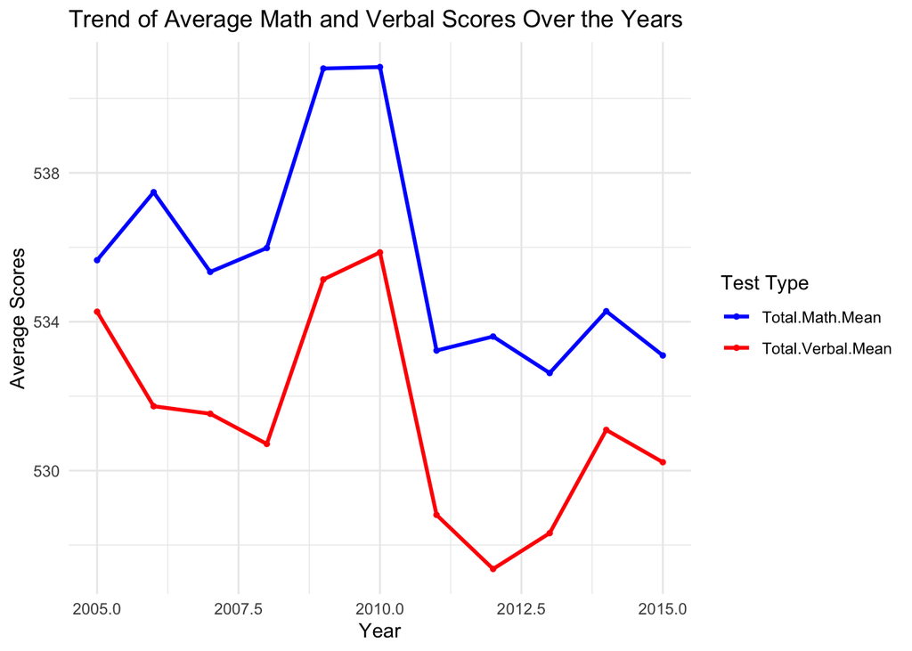

```r
score_trend_long <- score_subset %>%
  group_by(Year) %>%
  summarise(Total.Math.Mean = mean(Total.Math, na.rm = TRUE),
            Total.Verbal.Mean = mean(Total.Verbal, na.rm = TRUE)) %>%
  pivot_longer(cols = c(Total.Math.Mean, Total.Verbal.Mean),
               names_to = "Test_Type",
               values_to = "Mean_Scores")

# Plot the trend by year using ggplot2
ggplot(score_trend_long, aes(x = Year, y = Mean_Scores, color = Test_Type)) +
  geom_line(size = 1) +  # Create line plot
  geom_point(size = 1) +   # Add points for emphasis
  labs(title = "Trend of Average Math and Verbal Scores Over the Years",
       x = "Year", y = "Average Scores",
       color = "Test Type") +
  theme_minimal() +
  scale_color_manual(values = c("Total.Math.Mean" = "blue",
                                "Total.Verbal.Mean" = "red"))
```

We plotted another line graph to visualize the trend of total test takers over the years.The total number of test takers was calculated and summed for each year. The blue line represents the trend of total test takers over time, with points added to highlight the values for each year. The x-axis shows the year, while the y-axis represents the total number of test takers.

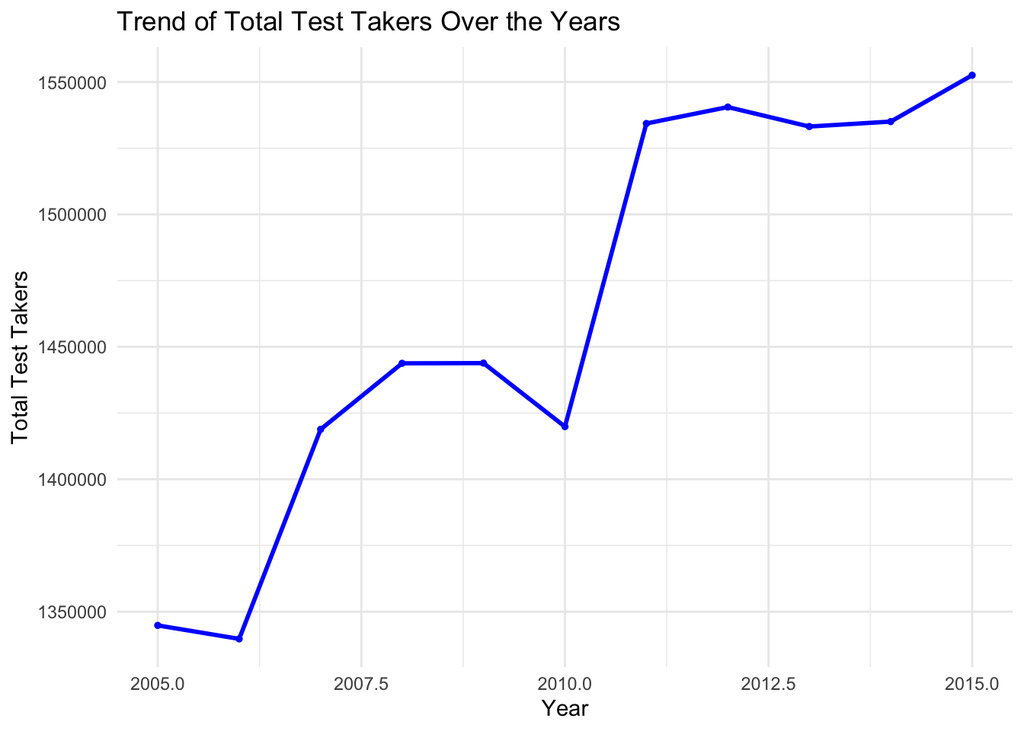

```r
testtaker_trend <- score_subset %>%
  group_by(Year) %>%
  summarise(Total.Test.Takers.Sum = sum(Total.Test.takers, na.rm = TRUE))

# Plot the trend by year using ggplot2
ggplot(testtaker_trend, aes(x = Year, y = Total.Test.Takers.Sum)) +
  geom_line(size = 1, color = "blue") +  # Create line plot
  geom_point(size = 1, color = "blue") +   # Add points for emphasis
  labs(title = "Trend of Total Test Takers Over the Years",
       x = "Year", y = "Total Test Takers") +
  theme_minimal()
```

### Gender Group Analysis

We plotted a pie chart to represent the distribution of test takers by gender. The chart is divided into two segments, each showing the proportion of male and female participants in the test.

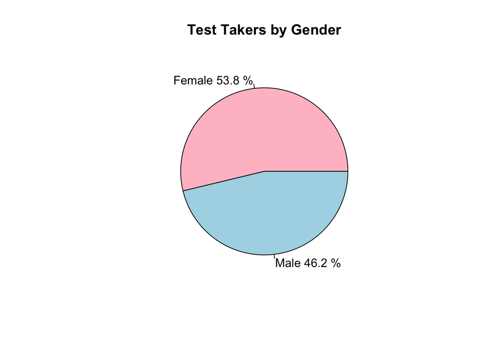

```r
gender_takers <- c(sum(test_score_data$Gender.Female.Test.takers, na.rm = TRUE),
                   sum(test_score_data$Gender.Male.Test.takers, na.rm = TRUE))
gender_labels <- c("Female", "Male")
# Calculate the total number of test takers
total_takers <- sum(gender_takers)

# Calculate the percentage for each gender
gender_percentages <- round(gender_takers / total_takers * 100, 1)

# Create labels that include both gender and percentage
gender_labels <- paste(gender_labels, gender_percentages, "%")

# Create the pie chart with percentages
pie(gender_takers, labels = gender_labels,
    main = "Test Takers by Gender",
    col = c("pink", "lightblue"))
```

From the pie chart, we can observe that there are slightly more female test takers compared to male test takers. This difference need to be further analyzed, so we then plot another chart to analysis the score difference between “Female” and “Male”. We calculated the mean math and verbal scores for both females and males and plot in bar graph.

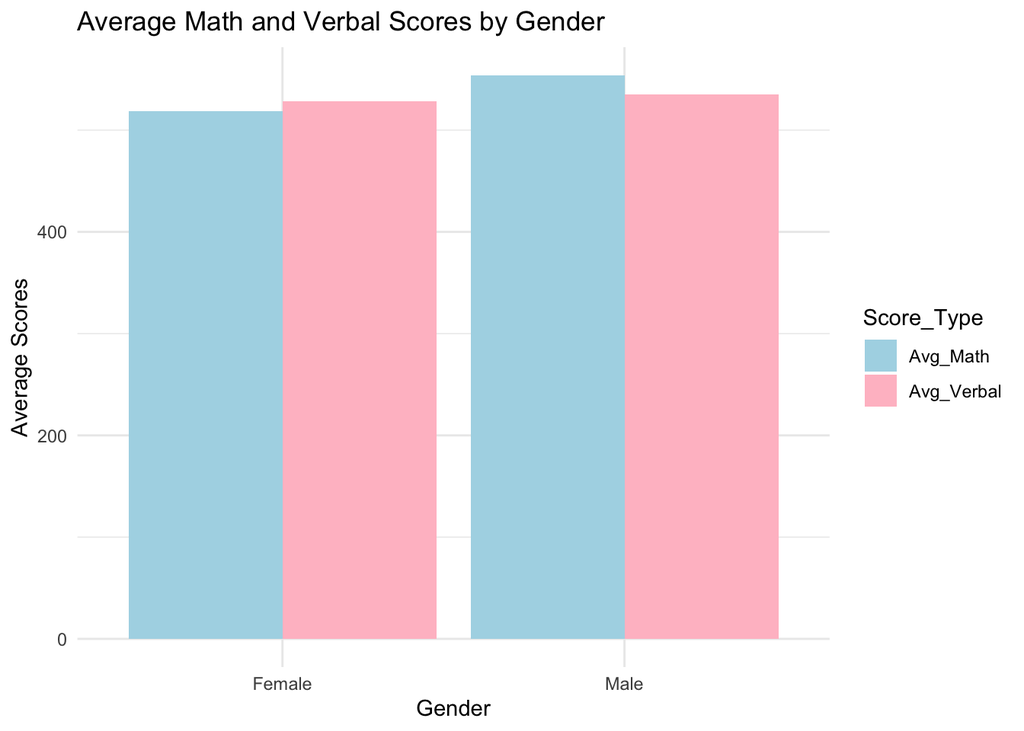

```r
# Calculate average math and verbal scores by gender
gender_scores <- data.frame(
  Gender = c("Female", "Male"),
  Avg_Math = c(mean(test_score_data$Gender.Female.Math, na.rm = TRUE),
               mean(test_score_data$Gender.Male.Math, na.rm = TRUE)),
  Avg_Verbal = c(mean(test_score_data$Gender.Female.Verbal, na.rm = TRUE),
                 mean(test_score_data$Gender.Male.Verbal, na.rm = TRUE))
)

gender_scores_long <- gender_scores %>%
  pivot_longer(cols = c(Avg_Math, Avg_Verbal),
               names_to = "Score_Type",
               values_to = "Average_Score")
# Plot using ggplot
ggplot(gender_scores_long, aes(x = Gender, y = Average_Score, fill = Score_Type)) +
  geom_bar(stat = "identity", position = "dodge") +
  labs(title = "Average Math and Verbal Scores by Gender",
       x = "Gender",
       y = "Average Scores") +
  scale_fill_manual(values = c("lightblue", "pink")) +
  theme_minimal()
```

```r
# Perform t-test for math scores
math_ttest <- t.test(test_score_data$Gender.Female.Math,
                     test_score_data$Gender.Male.Math,
                     na.rm = TRUE)

# Perform t-test for verbal scores
verbal_ttest <- t.test(test_score_data$Gender.Female.Verbal,
                       test_score_data$Gender.Male.Verbal,
                       na.rm = TRUE)

# Print the results of the t-tests
math_ttest
```

```
##
##  Welch Two Sample t-test
##
## data:  test_score_data$Gender.Female.Math and test_score_data$Gender.Male.Math
## t = -13.008, df = 1142.8, p-value < 2.2e-16
## alternative hypothesis: true difference in means is not equal to 0
## 95 percent confidence interval:
##  -40.84959 -30.14174
## sample estimates:
## mean of x mean of y
##  518.4159  553.9116
```

```r
verbal_ttest
```

```
##
##  Welch Two Sample t-test
##
## data:  test_score_data$Gender.Female.Verbal and test_score_data$Gender.Male.Verbal
## t = -2.4972, df = 1149.8, p-value = 0.01266
## alternative hypothesis: true difference in means is not equal to 0
## 95 percent confidence interval:
##  -11.670356  -1.400701
## sample estimates:
## mean of x mean of y
##  528.3484  534.8839
```

Math Scores: The p-value is smaller than 0.05, indicating a statistically significant difference between the math scores of females and males. The confidence interval does not contain 0, further supporting the conclusion that the true difference in means is significant. Males, on average, scored about 35 points higher than females in math (553.91 vs. 518.42).

Verbal Scores:The p-value (0.01266) is also smaller than 0.05, indicating a statistically significant difference between verbal scores for females and males. However, the difference is much smaller compared to math scores, with males scoring about 6.5 points higher than females on average.

## Theme 3: Academic Performance in Subjects

Our dataset also provides information on GPA and the number of years spent studying different subjects. The subjects include arts, English, foreign languages, mathematics, and natural sciences. Each subject has two variables:

- Academic.Subjects.English.Average.GPA: The average GPA of all students in this state during this year in English.
- Academic.Subjects.Mathematics.Average.GPA: The average GPA of all students in this state during this year in Math.

```r
academic_data <- score_subset[, academic_vars]
head(academic_data)
```

```
##   Academic.Subjects.English.Average.GPA
## 1                                  3.53
## 2                                  3.35
## 3                                  3.45
## 4                                  3.61
## 5                                  3.32
## 6                                  3.49
##   Academic.Subjects.Mathematics.Average.GPA
## 1                                      3.41
## 2                                      3.06
## 3                                      3.25
## 4                                      3.46
## 5                                      3.05
## 6                                      3.33
```

### Academic Performance vs. SAT score Analysis

We created two scatter plots to explore the relationship between SAT scores and academic GPA in specific subjects. The first plot shows the relationship between math scores and mathematics GPA, with the math scores on the x-axis and the average GPA in math on the y-axis. The second plot shows the relationship between verbal scores and English GPA, with verbal scores on the x-axis and the average GPA in English on the y-axis. Different colors and symbols are used to distinguish between the two subjects: blue for math and red for verbal scores.

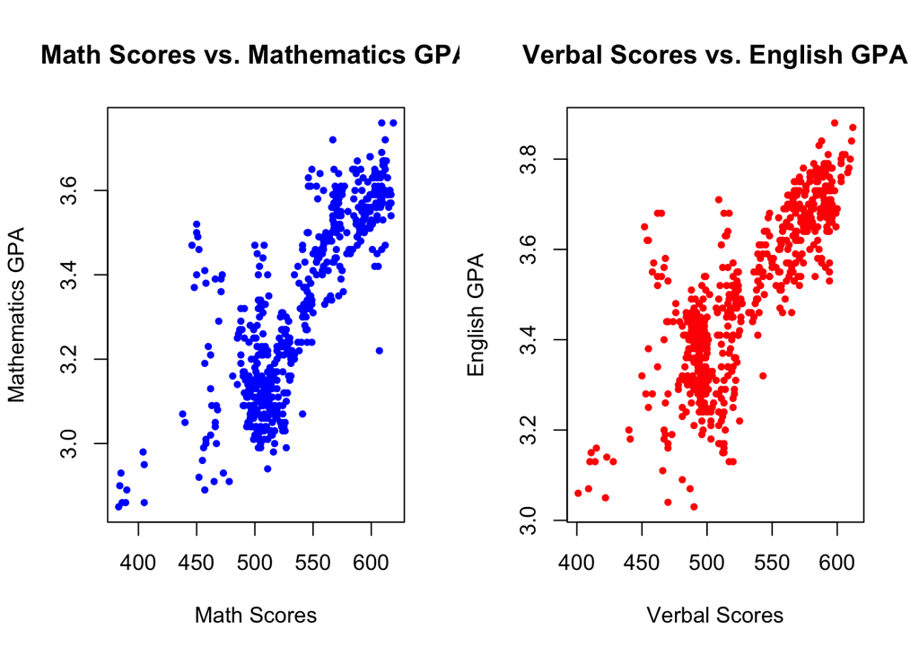

```r
par(mfrow = c(1, 2))

# Plot for Math Scores vs Mathematics GPA
plot(score_subset$Total.Math, score_subset$Academic.Subjects.Mathematics.Average.GPA,
     main = "Math Scores vs. Mathematics GPA",
     xlab = "Math Scores", ylab = "Mathematics GPA",
     pch = 19, col = "blue", cex = 0.6)

# Plot for Verbal Scores vs English GPA
plot(score_subset$Total.Verbal, score_subset$Academic.Subjects.English.Average.GPA,
     main = "Verbal Scores vs. English GPA",
     xlab = "Verbal Scores", ylab = "English GPA",
     pch = 19, col = "red", cex = 0.6)
```

```r
par(mfrow = c(1, 1))
```

From the plots, we can observe a positive relationship between SAT scores and GPA for both subjects. For math, higher SAT math scores are associated with higher mathematics GPAs, though the data appears more spread out. In contrast, the relationship between verbal scores and English GPA seems tighter, with a clearer upward trend, indicating a strong correlation between better verbal performance on the SAT and higher academic performance in English.

## Theme 4: Family Income Groups

Family income groups are crucial in understanding how socioeconomic factors influence student performance. Our dataset includes variables for different income brackets and their corresponding test scores:

```r
income_data <- score_subset[, income_vars]
head(income_data)
```

```
##   Family.Income.Between.20.40k.Math Family.Income.Between.20.40k.Test.takers
## 1                               513                                      324
## 2                               492                                      401
## 3                               498                                     2121
## 4                               513                                      180
## 5                               477                                    26161
## 6                               533                                      948
##   Family.Income.Between.20.40k.Verbal Family.Income.Between.40.60k.Math
## 1                                 527                               539
## 2                                 500                               517
## 3                                 495                               520
## 4                                 526                               543
## 5                                 458                               506
## 6                                 535                               543
##   Family.Income.Between.40.60k.Test.takers Family.Income.Between.40.60k.Verbal
```

[output cut: 55 more lines]

### Family Income Group Analysis

We get the number of test takers in each family income group, such as those earning less than 20k or more than 100k, excluding missing values. We then draw a pie chart to visualize the distribution of test takers across these income groups, helping to illustrate how the number of test takers varies by family income.

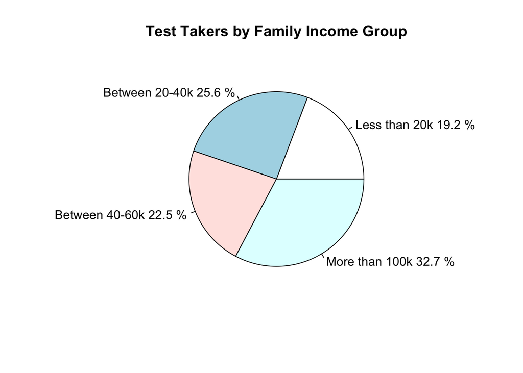

```r
income_takers <- c(sum(income_data$Family.Income.Less.than.20k.Test.takers, na.rm = TRUE),                    sum(income_data$Family.Income.Between.20.40k.Test.takers, na.rm = TRUE),                    sum(income_data$Family.Income.Between.40.60k.Test.takers, na.rm = TRUE),                    sum(income_data$Family.Income.More.than.100k.Test.takers, na.rm = TRUE))
income_labels <- c("Less than 20k", "Between 20-40k", "Between 40-60k", "More than 100k")
total_takers <- sum(income_takers)

# Calculate the percentage for each income group
income_percentages <- round(income_takers / total_takers * 100, 1)

# Create labels that include both income group and percentage
income_labels <- paste(income_labels, income_percentages, "%")

# Create the pie chart with percentages
pie(income_takers, labels = income_labels,
    main = "Test Takers by Family Income Group")
```

The pie chart shows that the distribution of test takers across income groups is fairly balanced, but the “More than 100k” group occupies the largest portion.

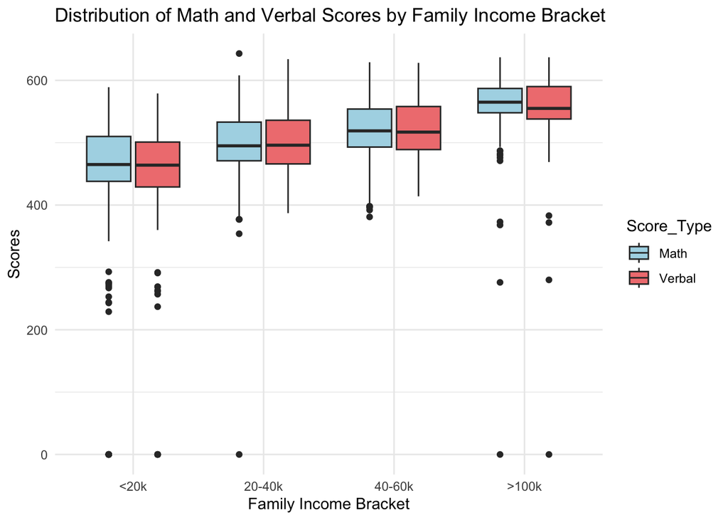

```r
income_data_long <- income_data %>%
  select(Family.Income.Less.than.20k.Math, Family.Income.Between.20.40k.Math,
         Family.Income.Between.40.60k.Math, Family.Income.More.than.100k.Math,
         Family.Income.Less.than.20k.Verbal, Family.Income.Between.20.40k.Verbal,
         Family.Income.Between.40.60k.Verbal, Family.Income.More.than.100k.Verbal) %>%
  pivot_longer(cols = everything(),
               names_to = c("Income_Bracket", "Score_Type"),
               names_pattern = "Family.Income.(.*)\\.(.*)",
               values_to = "Scores") %>%
  mutate(Income_Bracket = case_when(
    Income_Bracket == "Less.than.20k" ~ "<20k",
    Income_Bracket == "Between.20.40k" ~ "20-40k",
    Income_Bracket == "Between.40.60k" ~ "40-60k",
    Income_Bracket == "More.than.100k" ~ ">100k"
  )) %>%
   mutate(Income_Bracket = factor(Income_Bracket, levels = c("<20k", "20-40k", "40-60k", ">100k")))

# Create a boxplot for both Math and Verbal Scores by Family Income Bracket
ggplot(income_data_long, aes(x = Income_Bracket, y = Scores, fill = Score_Type)) +
  geom_boxplot() +
  labs(title = "Distribution of Math and Verbal Scores by Family Income Bracket",
       x = "Family Income Bracket", y = "Scores") +
  scale_fill_manual(values = c("Math" = "lightblue", "Verbal" = "lightcoral")) +
  theme_minimal()
```

## Theme 5: GPA-based Breakdown

Our dataset provides a breakdown of test scores based on GPA ranges. Students are categorized into groups based on their GPA, ranging from A+ to D or lower. This allows for analysis of how students in different GPA ranges perform on standardized tests:

- GPA.A(A.plus/A.minus/B/…/D.or.lower/No.response).Test.takers: The number of test-takers in this state during this year who reported this for their high school grade point average
- GPA.A(A.plus/A.minus/B/…/D.or.lower/No.response).Verbal: The average Verbal (Reading, not Writing) score of students in this state during this year who reported this for their high school grade point average
- GPA.A(A.plus/A.minus/B/…/D.or.lower/No.response).Math: The average math score of students in this state during this year who reported this for their high school grade point average

```r
gpa_data <- score_subset[, gpa_vars]
head(gpa_data)
```

```
##   GPA.A.minus.Math GPA.A.minus.Test.takers GPA.A.minus.Verbal GPA.A.plus.Math
## 1              569                     724                575             622
## 2              544                     673                546             600
## 3              541                    3334                535             605
## 4              559                     298                572             629
## 5              562                   30545                538             625
## 6              573                    2323                570             627
##   GPA.A.plus.Test.takers GPA.A.plus.Verbal GPA.A.Math GPA.A.Test.takers
## 1                    563               623        600              1032
## 2                    173               604        580               671
## 3                   1684               593        571              3854
## 4                    273               639        579               457
## 5                   7502               603        592             25546
## 6                   1098               614        602              2736
##   GPA.A.Verbal GPA.B.Math GPA.B.Test.takers GPA.B.Verbal GPA.C.Math
```

[output cut: 27 more lines]

### Average Math & Verbal Scores vs. GPA Analysis

We calculated the mean math score for each GPA category and plotted it in a bar plot. This visualization shows how math scores are distributed across GPA categories, with each bar representing the average math score for a specific GPA range (from “A+” to “D or lower”).

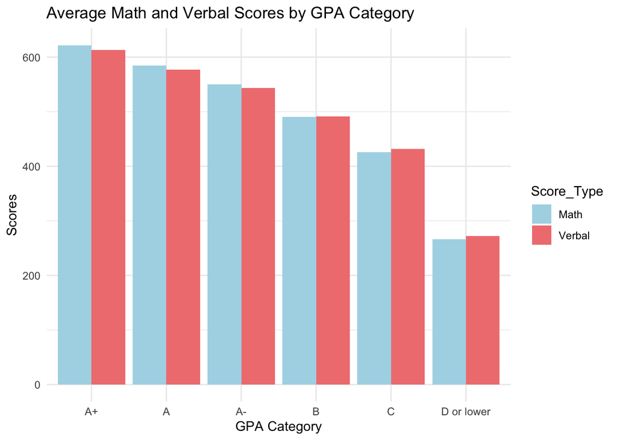

```r
gpa_data_long <- data.frame(
  GPA = rep(c("A+", "A", "A-", "B", "C", "D or lower"), 2),
  Score_Type = rep(c("Math", "Verbal"), each = 6),
  Scores = c(
    sapply(c("A.plus", "A", "A.minus", "B", "C", "D.or.lower"),
           function(grade) mean(gpa_data[[paste0("GPA.", grade, ".Math")]], na.rm = TRUE)),
    sapply(c("A.plus", "A", "A.minus", "B", "C", "D.or.lower"),
           function(grade) mean(gpa_data[[paste0("GPA.", grade, ".Verbal")]], na.rm = TRUE))
  )
)
gpa_data_long$GPA <- factor(gpa_data_long$GPA, levels = c("A+", "A", "A-", "B", "C", "D or lower"))

ggplot(gpa_data_long, aes(x = GPA, y = Scores, fill = Score_Type)) +
  geom_bar(stat = "identity", position = "dodge") +
  labs(title = "Average Math and Verbal Scores by GPA Category",
       x = "GPA Category", y = "Scores") +
  scale_fill_manual(values = c("Math" = "lightblue", "Verbal" = "lightcoral")) +
  theme_minimal()
```

We can observe a decreasing trend in the plot, indicating an association between GPA and math scores. The students with an “A+” GPA have the highest average math scores, while those in the “D or lower” category have the lowest. This suggests that students with higher GPAs tend to perform better in SAT math, and there’s a consistent drop in math scores as GPA decreases.

We calculated the mean verbal score for each GPA category and plotted it in a bar plot. This visualization shows how verbal scores are distributed across GPA categories, with each bar representing the average verbal score for a specific GPA range (from “A+” to “D or lower”).

From this figure, we can observe a decreasing trend in average verbal scores as GPA decreases, suggesting a positive correlation between GPA and verbal performance. Students with an “A+” GPA have the highest average verbal scores, while those in the “D or lower” category have the lowest. This indicates that students with higher GPAs tend to perform better in verbal assessments, and there is a consistent decline in scores as the GPA drops.、

# Limitation 1

We conducted a thorough analysis of the data from 2005 to 2015. When calculating averages, we averaged the data across these years since the dataset is panel data. While this approach may overlook some detailed year-to-year changes and trends, we believe it offers valuable insights into broader patterns in education that could inform the next decade.

# Further Discussion

Moreover, our results demonstrated a clear correlation between socioeconomic status and test performance. Families with higher incomes generally showed better outcomes with less variability in scores, suggesting that economic advantages translate into educational benefits. This link prompts further research into the specific resources and opportunities that higher income affords, such as access to quality after-school programs and enhanced parental involvement. Understanding these connections can inform policies aimed at leveling the educational playing field.

Additionally, the persistent performance gap highlighted by our decade-long dataset points to structural issues within the education system that may have been exacerbated by recent events like the COVID-19 pandemic. Comparing our data with more recent datasets could provide critical insights into how these disparities have shifted, helping policymakers address the current educational challenges more effectively.

Lastly, the potential effects of policy changes, such as increased funding for lower-income schools or the adoption of new educational technologies, deserve close scrutiny. Given the regional and income-related disparities we’ve observed, assessing the impact of these policies can determine their efficacy in mitigating educational inequities.

# Citation

Cory Bart, A. (2016). School_scores (2.0.0) [Dataset]. https://corgis-edu.github.io/corgis/csv/school_scores/